# Global Empirical Analysis: Relationship between Income & Life Expectancy

Deerasinghe T.

20/10/2024

## Research Outline

### Background

Life expectancy is the average number of years people live from birth. Life expectancy is a crucial indicator for evaluating public health and standard of living. High life expectancy is frequently associated with access to quality healthcare, clean water, nutritious food, and safe living conditions. In contrast, low life expectancy often correlates with limited access to these basic necessities. Therefore, it is essential to comprehend the impact of income on life expectancy to develop effective policies that reduce health disparities and improve population health.

### Research Question

Is income a significant factor for life expectancy?

### Research Objective

This research investigate the association between income and life expectancy, considering potential other predictors such as urbanisation, unemployment, health expenditure and region. The objective is to identify the effect of income and its interplay with other factors on life expectancy.

### Research Hypothesis

The primary hypothesis of this research is that individual income has a significant impact on life expectancy while controlling for other factors.

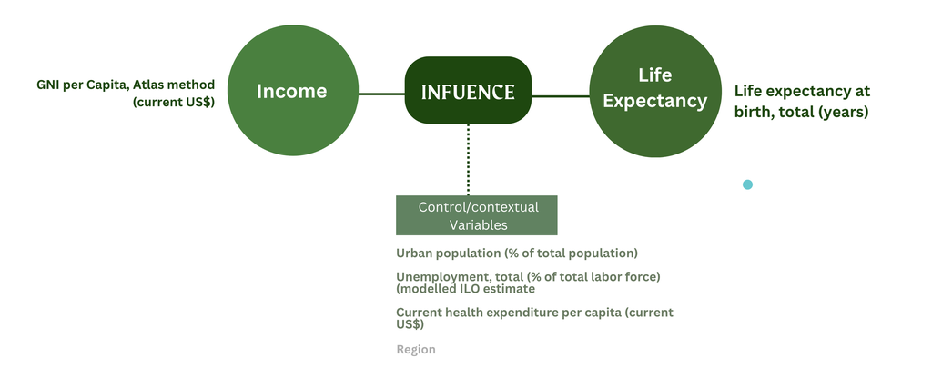

## Dataset & Variables

### Dataset

The dataset was created from World Bank Development Indicators, with values from 2021 used to create the dataset. The reason for using data from 2021 is that health expenditure data was only published up to that year.

### Variables Used

| Variable | Variable_Name | Description |
| --- | --- | --- |
| Life Expectancy at birth,total (years) | life_expectancy | Life expectancy at birth indicates the number of years a newborn infant would live if prevailing patterns of mortality at the time of its birth were to stay the same throughout its life. |
| Gross national income per capita (Atlas moethod) | GNIpc | GNI is the sum of value added by all resident producers plus any product taxes (less subsidies) not included in the valuation of output plus net receipts of primary income (compensation of employees a… |
| Urban population (% of total population) | urbanisation | Urban population refers to people living in urban areas as defined by national statistical offices. |
| Unemployment, total (% of total labor force) (modeled ILO estimate) | unemployment | Unemployment refers to the share of the labor force that is without work but available for and seeking employment. |
| Current health expenditure per capita (current US$) | healthexpenditure_pc | Current expenditures on health per capita in current US dollars. Estimates of current health expenditures include healthcare goods and services consumed during each year. |

### Why these variables used for analysis?

GNI per capita, urbanization, unemployment, and health expenditure per capita are socio-economic factors that can provide valuable insights into factors that affect life expectancy. Higher GNI per capita is typically associated with better access to healthcare, healthier lifestyles, and overall better living conditions (Aimbetova, 2022), all of which can lead to increased life expectancy. Urbanization is also an important factor to consider, as it can affect access to healthcare and living conditions (Godfrey & Julien, 2005). Unemployment, on the other hand, can be a negative factor for life expectancy. Being unemployed can lead to stress, reduced income, and fewer opportunities to access healthcare (Wilson & Walker, 1993). Health expenditure is often considered a key indicator of the quality and accessibility of healthcare (Onofrei et al., 2021). Higher health expenditure per capita may lead to improved access to healthcare, better disease prevention and treatment, and ultimately, increased life expectancy.

## Data Cleaning

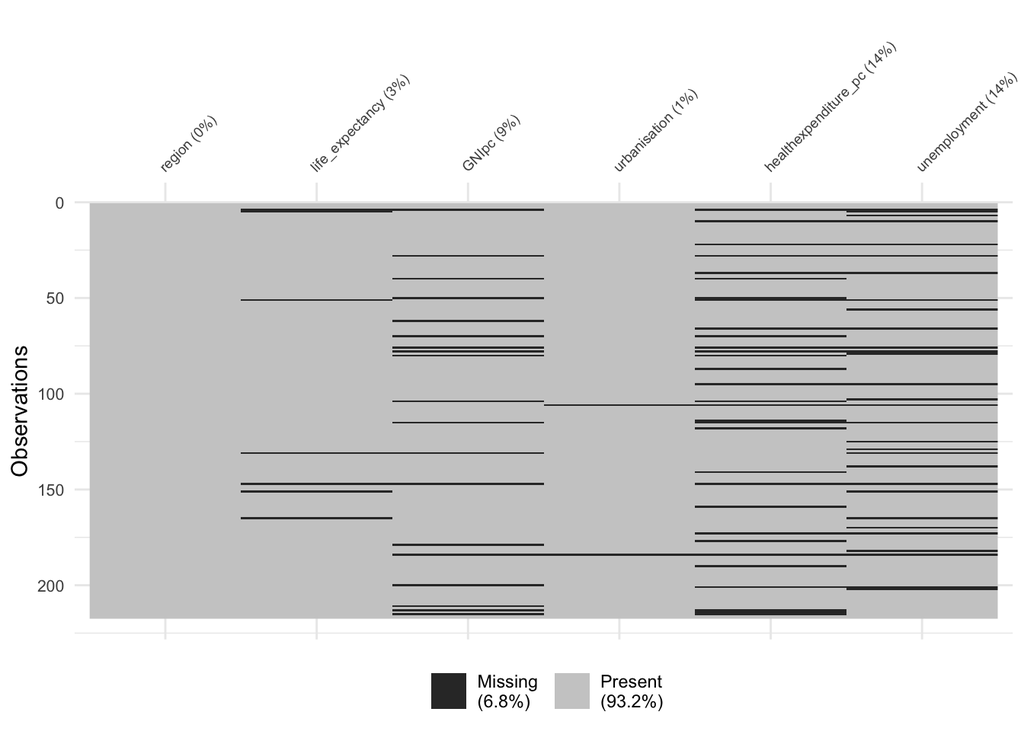

- Countries where life expectancy values is missing were removed and other variables were imputed using tree based imputation method using recipe functions in R.
- According to the World Bank regions South Asia region and North America regions have only few countries (8 and 3 respectively). This data imbalance might be problematic for model building process. Therefore based on the geographical location regions South Asia was merged together with East Asia & Pacific; and North America was merged together with Europe & Central Asia.

Mapping of Regions to New Names

[output not shown]

## Summary Statistics

Summary Statistics for Life Expectancy, GNIpc, Urbanisation, and Unemployment

|  | Variable | Mean | Median | Min | Max | SD | Skewness |
| --- | --- | --- | --- | --- | --- | --- | --- |
| life_expectancy | life_expectancy | 71.755 | 72.461 | 52.525 | 85.533 | 7.663 | -0.337 |
| GNIpc | GNIpc | 16584.513 | 6440.000 | 220.000 | 122670.000 | 21833.485 | 1.891 |
| urbanisation | urbanisation | 60.760 | 62.073 | 13.456 | 100.000 | 23.445 | -0.158 |
| unemployment | unemployment | 7.996 | 6.200 | 0.140 | 35.707 | 5.698 | 1.639 |

## Exploratory Data Analysis

### Distribution of Life Expectancy

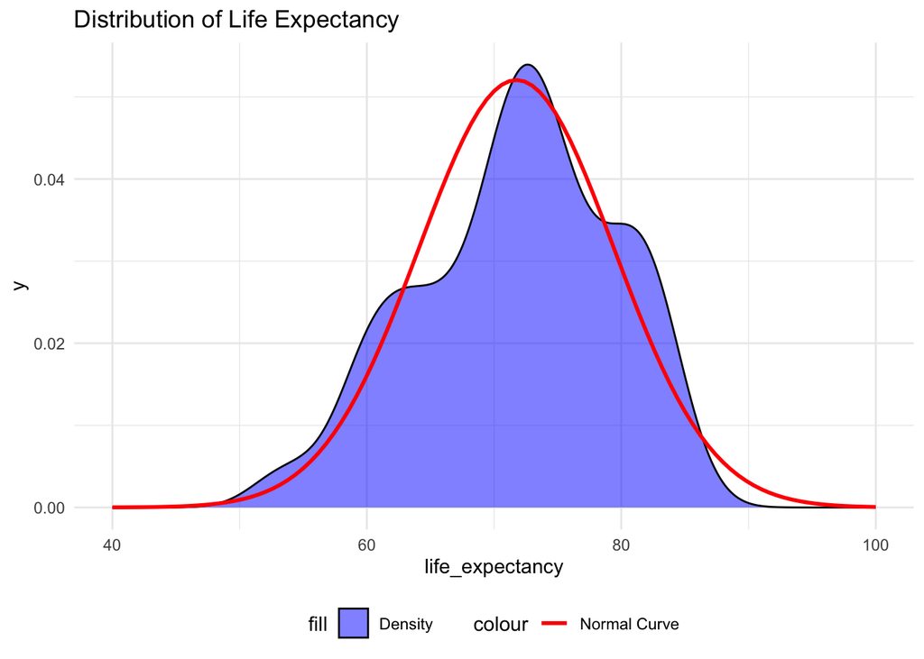

Skewness = -0.3366

- Distribution of the life expectancy shows a slight symmetrical distribution and deviates from the normal distribution. The skewness value of -0.3366 for the `life_expectancy` variable indicates a slight left skew in the distribution of the data. This negative skewness suggests that the left tail of the distribution is longer or more pronounced than the right tail, implying that there are a few observations with lower life expectancy that are pulling the average down. However, the value is relatively close to zero, indicating that the skewness is not very pronounced and that the distribution is mostly symmetric. And also, there are multiple peaks (multi-model distribution) in the distribution showing there should be an effect of a categorical variable which affects the distribution of `life_expectancy` .

### Boxplots of Life Expectancy in different Regions

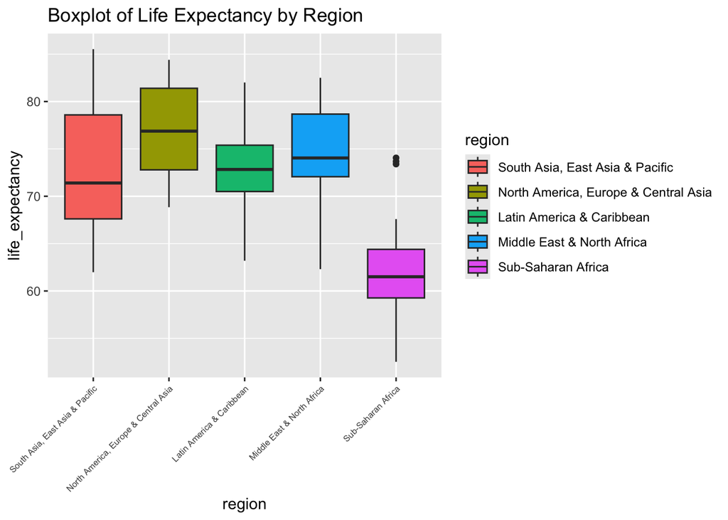

- `life_expectancy` of the region `Sub-Saharan Africa` is significantly lower that the other regions and `life_expectancy` is approximately equal in all the other regions.

### Correlation Matrix

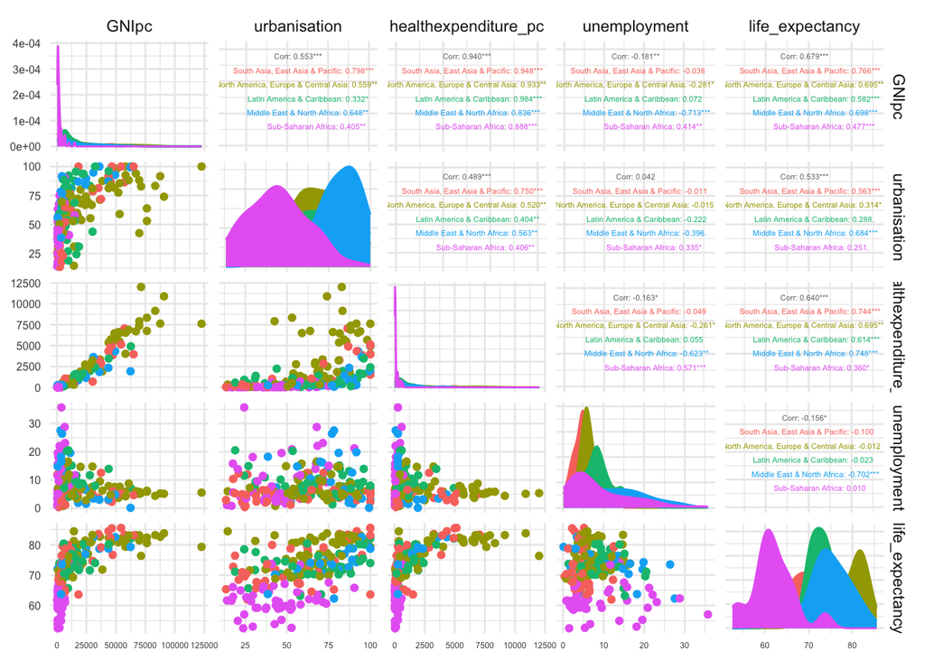

## Analysis Results

### Model level statistics

| r.squared | adj.r.squared | sigma | statistic | p.value | df |
| --- | --- | --- | --- | --- | --- |
| 0.7370908 | 0.7254429 | 4.032968 | 63.28113 | 0 | 7 |

The regression analysis yields an R-squared value of approximately 0.7371, indicating that about 73.71% of the variability in life expectancy can be explained by the model’s predictors. This suggests that the model fits the data well and that the predictors have a substantial effect on life expectancy. The standard error of the regression (sigma) is approximately 4.03, indicating that the predicted life expectancy values are, on average, about 4.03 units away from the actual observed values. The F-statistic is 63.28113, which signifies that the overall model is statistically significant, as it is considerably greater than 1, implying that at least one of the predictors in the model has a meaningful relationship with life expectancy. The associated p-value of 0 provides strong evidence against the null hypothesis, suggesting that the model offers a significantly better fit to the data than a model with no predictors. Overall, these results demonstrate the effectiveness of the model in explaining the variations in life expectancy based on predictors GNI per capita, urban population, region and unemployment.

### Component level statistics

Newey-West standard errors for the OLS model

| Term | Estimate | Std_Error | t_value | P_Value |
| --- | --- | --- | --- | --- |
| (Intercept) | 68.5911 | 0.9168 | 74.8137 | 0.0000* |
| GNIpc | 0.0001 | 0.0000 | 6.6355 | 0.0000* |
| urbanisation | 0.0580 | 0.0159 | 3.6413 | 0.0004* |
| unemployment | 0.0155 | 0.0649 | 0.2393 | 0.8112 |
| regionLAC | -0.8716 | 0.8108 | -1.0749 | 0.2840 |
| regionMNA | -0.5980 | 0.9056 | -0.6604 | 0.5100 |
| regionSA & EAP | -0.4770 | 0.9073 | -0.5258 | 0.5998 |
| regionSSA | -9.7238 | 1.0565 | -9.2037 | 0.0000* |

* represents significance under 0.05 level.

#### Model Equation

$$\hat{Y} = 68.5911 + 0.0001 \times \text{GNIpc} + 0.0580 \times
\text{urbanisation
} + 0.0155 \times \text{unemployment}$$
$$- 0.8716 \times \text{region LAC} - 0.5980 \times \text{region MNA}$$
$$- 0.4770 \times \text{region SA and EAP} - 9.7238 \times \text{region
SSA}$$

Where:

- $\hat{Y}$ is the predicted life expectancy.
- **GNIpc** is the Gross National Income per Capita.
- **urbanisation** Urban population (% of total population).
- **unemployment** is Unemployment, total (% of total labor force).

**Region Dummy Variables**

The region dummy variables are encoded as follows:

- **regionLAC** = 1 if the region is **Latin America & Caribbean**; 0 otherwise.
- **regionMNA** = 1 if the region is **Middle East & North Africa**; 0 otherwise.
- **regionSA_EAP** = 1 if the region is **South Asia**, **East Asia & Pacific**; 0 otherwise.
- **regionSSA** = 1 if the region is **Sub-Saharan Africa**; 0 otherwise.

The reference region is **EAC & NAR** (Europe & Central Asia & North America). Research selected **EAC & NAR region** because this region has the highest life expectancy among all regions, therefore is a good candidate for reference.

#### Model Interpretation

The model explores how life expectancy is influenced by GNI per capita, urban population, unemployment, and regional differences. Using EAC & NAR (Europe & Central Asia and North America) as the reference region, the intercept of 68.59 represents the estimated life expectancy in this region when all other predictors are at zero. GNI per capita has a significant positive effect (p-value = 0.0000), suggesting that higher GNI per capita is associated with increased life expectancy, though the effect size is small at 0.0001 per unit increase. Urban population also has a positive and significant effect (0.058, p-value = 0.0004), indicating that for every 1 unit increase in urban population, life expectancy increases by 0.058 years. Unemployment, however, is not statistically significant (p-value = 0.8112), implying it has no meaningful impact on life expectancy in this model.

Regarding regional differences, LAC (Latin America & Caribbean) has a negative coefficient (-0.8716) but is not statistically significant (p-value = 0.2840), suggesting no meaningful difference in life expectancy compared to EAC & NAR. Similarly, MNA (Middle East & North Africa, -0.5980, p-value = 0.5100) and SA & EAP (South Asia & East Asia & Pacific, -0.4770, p-value = 0.5998) show no significant differences from the reference region. However, SSA (Sub-Saharan Africa) has a large and significant negative effect (-9.7238, p-value = 0.0000), indicating that life expectancy in SSA is approximately 9.72 years lower than in EAC & NAR, underscoring the significant disparity in health outcomes between these regions.

### Final Model Selection

In the model-building process, health expenditure was initially excluded from the OLS model due to multicollinearity. To improve predictive accuracy, log transformations were applied to variables, reducing skewness and improving performance without introducing bias. Regularization technique, Elastic Net, which combines ridge and lasso methods, were employed to address multicollinearity and reduce variance, though they added some bias. As a result, ridge and lasso were not considered separately. This regularized regression method is more complex and harder to interpret than OLS models. The trade-off between bias and variance was considered, with Elastic Net providing a more stable solution. OLS assumptions, including normality, homoscedasticity, and independence of errors and multicolinearity between predictors were also carefully examined to ensure model validity. Model selection was based on R-squared, RMSE, and MAPE, providing a balanced view of fit, prediction error, and accuracy.

## Conclusion

### Salient Findings

1. The research found out that GNI per capita has a significant positive effect, suggesting that higher GNI per capita is associated with increased life expectancy, though the effect size is small. GNI per capita and its significant effect on life expectancy aligns with the findings of Mondal and Shitan (2013) and Chetty et al. (2016). Governments should develop effective policies that reduce health disparities and improve population health for low income individuals and populations.
2. Urban population also has a positive significant effect, indicating that for every 1 unit increase in urban population, life expectancy increases by 0.058 years. The significant impact of Urbanization on life expectancy aligns with the findings of Ahmad et al. (2023). Governments should develop effective policies for people in rural areas that reduce health disparities and improve population health.
3. However, unemployment is has no significant which implies that it has no meaningful influence on life expectancy.
4. All regions except SSA (Sub-Saharan Africa), show no significant effect on life expectancy from the reference region EAC & NAR (Europe & Central Asia & North America). However, SSA (Sub-Saharan Africa) has a large 9.72 years lower life expectancy than in EAC & NAR; and significant negative effect on life expectancy indicating the significant disparity in health outcomes between these regions.

### Limitations

1. **Data Limitations**

   Research had to exclude variables such as poverty and income inequality due to lack of data availability. The lack of individual-level data on socioeconomic factors, the true impact of income on life expectancy was the other data limitation. The reliance on country-based measures of income in the analysis further highlights the limitations of the data.
2. **Robustness of the Model**

   Final model had to exclude variable health expenditure per capita data due to mutlicolinearity with GNI per capita. Also the final model has serial correlation, also known as autocorrelation, occurs when the regression residuals are correlated with each other. However, autocorrelation was corrected during the modeling process.

## Appendix

### Spliting the data

- Data was split as 80% to training data set and 20% to testing data set using stratified sampling method
- After the split two training and testing data sets were saved into separate csv files.

```r
#set.seed(123)  # For reproducibility
#split_data <- initial_split(final_data, prop = 0.8, strata = life_expectancy)
#train_data <- training(split_data)
#test_data <- testing(split_data)

# Save the training dataset to a CSV file
#write.csv(train_data, "train_data.csv", row.names = TRUE)

# Save the testing dataset to a CSV file
#write.csv(test_data, "test_data.csv", row.names = TRUE)

train_data <- read_csv("train_data.csv")
test_data <- read_csv("test_data.csv")
```

### OLS modeling

#### Initial OLS modeling

- Two OLS models were fitted under the OLS modeling. To address the issue of multicollinearity due the correlation between variable `GNIpc` and `healthexpenditure_pc` , variable `healthexpenditure_pc` was dropped becauese `GNIpc` is the main variable of interest in our analysis.
- OLS_model was fitted without applying any transformations to the predictor and LOG_model was fitted after normalizing all the variables by applying log transformation. Log transformation was applied to fix skewness identified during Exploratory Data Analysis.

```r
OLS_model <- lm((life_expectancy) ~ (GNIpc)+ (urbanisation)
             + (unemployment)+(region), data = train_data)


LOG_model <- lm(log(life_expectancy) ~ log(GNIpc)+ log(urbanisation)
             + log(unemployment)+(region), data = train_data)
```

```r
summary(OLS_model)
```

```
Call:
lm(formula = (life_expectancy) ~ (GNIpc) + (urbanisation) + (unemployment) +
    (region), data = train_data)

Residuals:
     Min       1Q   Median       3Q      Max
-11.0861  -2.2481   0.0846   2.5079  10.9974

Coefficients:
                 Estimate Std. Error t value Pr(>|t|)
(Intercept)     6.859e+01  1.306e+00  52.518  < 2e-16 ***
GNIpc           1.295e-04  1.863e-05   6.955 8.83e-11 ***
urbanisation    5.797e-02  1.781e-02   3.255  0.00139 **
unemployment    1.553e-02  6.033e-02   0.257  0.79714
regionLAC      -8.716e-01  1.028e+00  -0.848  0.39778
regionMNA      -5.980e-01  1.218e+00  -0.491  0.62419
regionSA & EAP -4.770e-01  9.933e-01  -0.480  0.63170
regionSSA      -9.724e+00  1.029e+00  -9.448  < 2e-16 ***
---
Signif. codes:  0 '***' 0.001 '**' 0.01 '*' 0.05 '.' 0.1 ' ' 1

Residual standard error: 4.033 on 158 degrees of freedom
Multiple R-squared:  0.7371,    Adjusted R-squared:  0.7254
F-statistic: 63.28 on 7 and 158 DF,  p-value: < 2.2e-16
```

```r
summary(LOG_model)
```

```
Call:
lm(formula = log(life_expectancy) ~ log(GNIpc) + log(urbanisation) +
    log(unemployment) + (region), data = train_data)

Residuals:
      Min        1Q    Median        3Q       Max
-0.174763 -0.028168  0.004474  0.032427  0.143059

Coefficients:
                    Estimate Std. Error t value Pr(>|t|)
(Intercept)        3.8682758  0.0498332  77.625  < 2e-16 ***
log(GNIpc)         0.0412822  0.0046108   8.953 9.00e-16 ***
log(urbanisation)  0.0160339  0.0124513   1.288    0.200
log(unemployment)  0.0002083  0.0057482   0.036    0.971
regionLAC         -0.0166939  0.0135175  -1.235    0.219
regionMNA          0.0012482  0.0162147   0.077    0.939
regionSA & EAP    -0.0034634  0.0136252  -0.254    0.800
regionSSA         -0.1102455  0.0155917  -7.071 4.69e-11 ***
---
Signif. codes:  0 '***' 0.001 '**' 0.01 '*' 0.05 '.' 0.1 ' ' 1

Residual standard error: 0.05511 on 158 degrees of freedom
Multiple R-squared:  0.7633,    Adjusted R-squared:  0.7528
F-statistic: 72.79 on 7 and 158 DF,  p-value: < 2.2e-16
```

### Regularized Regression

```r
# Convert the categorical variable 'region' into dummy variables and remove the intercept (-1)
X <- model.matrix(life_expectancy ~ region + GNIpc + urbanisation + healthexpenditure_pc + unemployment - 1,
                  data = train_data)

# Response variable
Y <- train_data$life_expectancy

set.seed(123)  # Ensures the training/testing split and cross-validation are reproducible
# Fit the Elastic Net model with cross-validation
cv_glmnet <- train(
  x = X,                   # Predictor matrix (now with dummy variables)
  y = Y,                   # Response variable
  method = "glmnet",        # Elastic Net model
  preProc = c("zv", "center", "scale"),  # Preprocessing: remove zero variance, center, and scale
  trControl = trainControl(method = "cv", number = 10),  # 10-fold cross-validation
  tuneLength = 10          # Test 10 different combinations of alpha and lambda
)
```

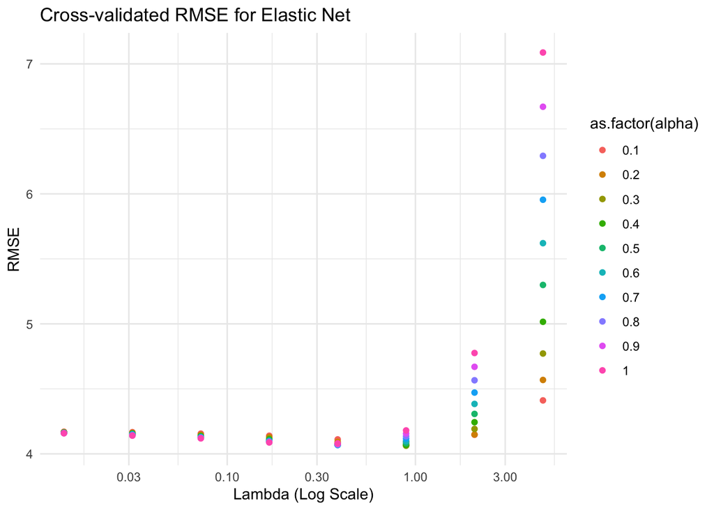

```r
# Ensure that lambda is numeric in the plot
ggplot(cv_glmnet$results, aes(x = as.numeric(lambda), y = RMSE, color = as.factor(alpha))) +
  geom_point() +
  scale_x_log10() +
  labs(title = "Cross-validated RMSE for Elastic Net",
       x = "Lambda (Log Scale)", y = "RMSE") +
  theme_minimal()
```

```r
# View the results for the best alpha and lambda combination

filtered_results <- cv_glmnet$results %>%
  filter(alpha == cv_glmnet$bestTune$alpha, lambda == cv_glmnet$bestTune$lambda)

 filtered_results
```

```
  alpha    lambda     RMSE  Rsquared      MAE    RMSESD RsquaredSD     MAESD
1   0.3 0.8920806 4.062419 0.7365538 3.155271 0.6385746  0.1102284 0.5621782
```

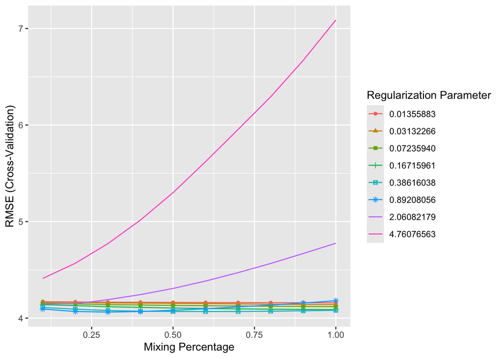

```r
ggplot(cv_glmnet)
```

#### Feature Interpretation using Net Elastic Model

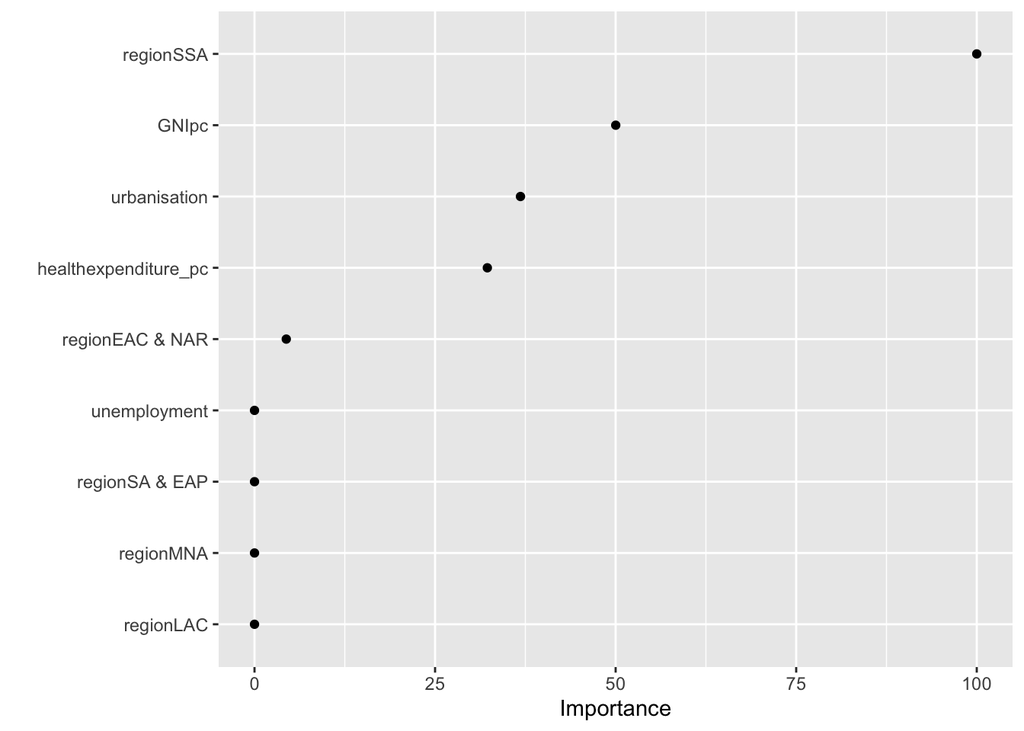

```r
vip(cv_glmnet,geom = "point")
```

- Based on the feature importance plot of the ‘Elastic Net’ regularization model the main variable of interest shows a significance importance. Among the control variables variables urban population and health expenditure shows a greater importance compared to the other models. The significant impact of Health Expenditure on life expectancy also aligns with the findings of Ahmad et al. (2023). The high magnitude of the standardized coefficients of SSA, which represents the region `Sub-Saharan Africa` is the most important variable.

### Model Comparison

- Performance of the all the models, including OLS and Regularized models were evaluated based on the `Root Mean Square Error (RMSE)` and `Mean Absolute Percent Error` using the testing data set. And, also `coefficient of variation` of the models, which are calculated based on the training data also used to measure the model performence using in sample fit of the models.

```r
# Create a table with RMSE, MAPE, and R-squared for all models
results <- data.frame(
  Model = c("OLS Model", "OLS Model 2 (log transformed)", "Regularized - Elastic Net"),
  RMSE = c(rmse_OLS_model, rmse_LOG_model, rmse_elastic_net),
  MAPE = c(mape_OLS_model, mape_LOG_model, mape_elastic_net),
  R_Squared = c(rsq_OLS_model, rsq_LOG_model, rsq_elastic_net)
)

# Display the results table
knitr::kable(results, caption = "Evaluation Metrics for Models")
```

Evaluation Metrics for Models

| Model | RMSE | MAPE | R_Squared |
| --- | --- | --- | --- |
| OLS Model | 4.531250 | 0.0463307 | 0.7370908 |
| OLS Model 2 (log transformed) | 4.217298 | 0.0449068 | 0.7633118 |
| Regularized - Elastic Net | 4.601839 | 0.0472655 | 0.7365538 |

- Based on RMSE, MAPE and R squared values both OLS models performs better than the regularized Net Elastic model. There for OLS models are suitable for make inferences due to their interpretability and better performance

#### Model Validation

- Among the OLS models model with normalized variables with log transformation performs better but there is no significance difference between the performance compared to the other model. Therefore to select the better model for making inferences model validation was carried out using Shapiro-Wilk test for Normality, Breusch-Pagan test for heteroskadasticity, Breusch-Godfrey test for serial correlation. And also, variance inflation factors were calculated to check for multicollinearity.

Model Validation Test (* shows significance under 0.05 level of significance) Results

| Test | Statistic | P_Value | Model |
| --- | --- | --- | --- |
| Shapiro-Wilk | 0.9900385 | 0.2963 | OLS_model |
| Breusch-Pagan | 11.6180336 | 0.1138 | OLS_model |
| BG Test | 4.4110358 | 0.0357* | OLS_model |
| Shapiro-Wilk | 0.9873519 | 0.1403 | LOG_model |
| Breusch-Pagan | 26.1260800 | 5e-04** | LOG_model |
| BG Test | 1.5277232 | 0.2165 | LOG_model |

* represents significance under 0.05 level and ** represents significant under 0.01 level of significance.

VIF values for OLS_model

|  | GVIF | Df | GVIF..1..2.Df.. |
| --- | --- | --- | --- |
| GNIpc | 1.845302 | 1 | 1.358419 |
| urbanisation | 1.738964 | 1 | 1.318698 |
| unemployment | 1.152088 | 1 | 1.073354 |
| region | 1.771633 | 4 | 1.074105 |

VIF values for LOG_model

|  | GVIF | Df | GVIF..1..2.Df.. |
| --- | --- | --- | --- |
| log(GNIpc) | 2.305957 | 1 | 1.518538 |
| log(urbanisation) | 1.766860 | 1 | 1.329233 |
| log(unemployment) | 1.091946 | 1 | 1.044962 |
| region | 2.010753 | 4 | 1.091239 |

- Both models do not violate the normality of the error term or the assumption of no multicollinearity. However, the OLS model violates the assumption of no serial correlation in the error terms, while the LOG model does not meet the homoscedasticity assumption at the 0.05 level of significance. Notably, the OLS model does not violate any assumptions at the 0.01 level of significance. Consequently, the OLS model is utilized for making inferences, and Newey-West standard errors were applied to correct for the serial correlation violation prior to making inferences.

```r
# Obtain Newey-West standard errors for the OLS model
newey_west_se <- NeweyWest(OLS_model)

# Coefficients with Newey-West standard errors
coeftest(OLS_model, vcov = newey_west_se)
```

```
t test of coefficients:

                  Estimate  Std. Error t value  Pr(>|t|)
(Intercept)     6.8591e+01  9.1683e-01 74.8137 < 2.2e-16 ***
GNIpc           1.2954e-04  1.9523e-05  6.6355 4.894e-10 ***
urbanisation    5.7974e-02  1.5921e-02  3.6413 0.0003672 ***
unemployment    1.5534e-02  6.4915e-02  0.2393 0.8111824
regionLAC      -8.7160e-01  8.1083e-01 -1.0749 0.2840387
regionMNA      -5.9805e-01  9.0563e-01 -0.6604 0.5099778
regionSA & EAP -4.7703e-01  9.0730e-01 -0.5258 0.5997842
regionSSA      -9.7238e+00  1.0565e+00 -9.2037 < 2.2e-16 ***
---
Signif. codes:  0 '***' 0.001 '**' 0.01 '*' 0.05 '.' 0.1 ' ' 1
```

## Reference List

Ahmad, N., Raid, M., Alzyadat, J. et al. Impact of urbanization and income inequality on life expectancy of male and female in South Asian countries: a moderating role of health expenditures. Humanit Soc Sci Commun 10, 552 (2023). https://doi.org/10.1057/s41599-023-02005-1

Aimbetova, G., Dossybayeva, G., Suleimenova, R., Turgambayeva, A., & Turgambayeva, A. (2022). Life Expectancy as a Quality of Life Indicator. Iranian Journal of Public Health, 51(5). https://doi.org/10.18502/ijph.v51i5.9442

Chetty, R., Stepner, M., Abraham, S., Lin, S., Scuderi, B., Turner, N., Bergeron, A., & Cutler, D. (2016). The Association between Income and Life Expectancy in the United States, 2001-2014. JAMA, 315(16), 1750–1766. https://doi.org/10.1001/jama.2016.4226

Godfrey, R., & Julien, M. (2005). Urbanisation and health. Clinical medicine (London, England), 5(2), 137–141. https://doi.org/10.7861/clinmedicine.5-2-137

Mondal, M. N., & Shitan, M. (2013). Impact of Socio-Health Factors on Life Expectancy in the Low and Lower Middle Income Countries. Iranian journal of public health, 42(12), 1354–1362.

Onofrei, M., Vatamanu, A. F., Vintilă, G., & Cigu, E. (2021). Government Health Expenditure and Public Health Outcomes: A Comparative Study among EU Developing Countries. International journal of environmental research and public health, 18(20), 10725. https://doi.org/10.3390/ijerph182010725

Salehi, M., Aziz-Mohammadilooha, M., Masaebi, F., & Zayeri, F. (2022). Six-Decade Trend Analysis of Life Expectancy at Birth in Asia, Regions of Asia and Iran: A Joinpoint Analysis. Medical Journal of the Islamic Republic of Iran. https://doi.org/10.47176/mjiri.36.166

Wilson, S. H., & Walker, G. M. (1993). Unemployment and health: a review. Public health, 107(3), 153–162. https://doi.org/10.1016/s0033-3506(05)80436-6